# ReproduceYostIndex Walkthrough

### Choosing a Yost variant

Pick the column that fits your analysis:

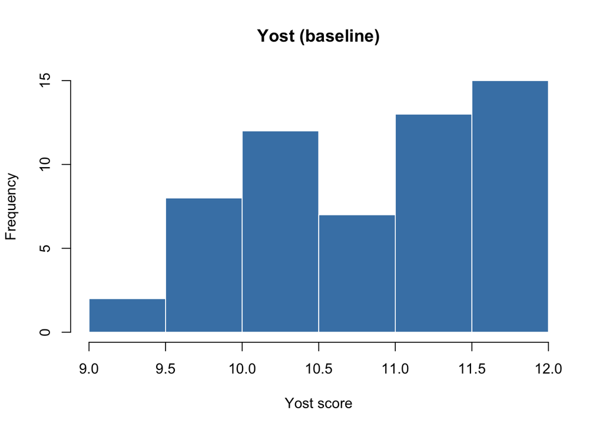

```r
df <- getYostIndex(geo = "county", year = 2022, states = "CA")

# For most county/tract analyses: plain Yost
hist(df$Yost, main = "Yost (baseline)", xlab = "Yost score", col = "steelblue", border = "white")
```

```r
# For block groups or small-sample tracts: stabilized variant
# df$YostStabilized  — shrinks unreliable estimates toward their parent geography

# When there are many NAs: imputed variant
# df$YostImputed     — fills missing values via spatial mean of neighbors
```

### Caching

Files are downloaded once and cached locally. Subsequent calls with the same arguments return instantly:

```r
# First call: downloads ~2 MB file
df <- getYostIndex(geo = "county", year = 2022)

# Second call: reads from cache — instantaneous
df <- getYostIndex(geo = "county", year = 2022)

# Force a fresh download
df <- getYostIndex(geo = "county", year = 2022, cache = FALSE)

# See where the cache lives
tools::R_user_dir("ReproduceYostIndex", "cache")
```

## `computeYostIndex()` — Full Pipeline

Use `computeYostIndex()` when: - You need **county-level scope** (quintiles & factor within each county) - You want to **inspect intermediate outputs** (raw ACS values, factor loadings, imputed data,the 7 yost variables) - You are building a **custom pipeline** and need fine-grained control. You may choose to change from `rank` to `standardize`, or to use `average` instead of weighted average per `total_population`

### Census API key (required)

```r
# Get a free key at: https://api.census.gov/data/key_signup.html
tidycensus::census_api_key("YOUR_KEY_HERE", install = TRUE)
```

### Basic usage

```r
yost_ca <- computeYostIndex(
  geo       = "tract",
  year      = 2022,
  states    = "CA",
  scope     = "state",
  stabilize = TRUE,    # empirical Bayes stabilization
  impute    = TRUE,    # spatial imputation for missing values
  keep_geometry = TRUE
)
```

```r
# Baseline (always present — no stabilization, no imputation)
head(yost_ca$df_yost_raw)
```

```
# A tibble: 6 × 4
  GEOID        Yost YostQuintile annotation
  <chr>       <dbl> <fct>        <chr>
1 06001400100  11.7 5            Complete data
2 06001400200  11.6 5            Complete data
3 06001400300  11.4 5            Complete data
4 06001400400  11.4 5            Complete data
5 06001400500  10.7 4            Complete data
6 06001400600  11.2 5            Complete data
```

```r
# Requested variant (stabilize = TRUE, impute = TRUE)
head(yost_ca$df_yost)
```

```
# A tibble: 6 × 4
  GEOID       YostStabilizedImputed YostStabilizedImputedQuintile annotation
  <chr>                       <dbl> <fct>                         <chr>
1 06001400100                  11.7 5                             Complete data
2 06001400200                  11.6 5                             Complete data
3 06001400300                  11.4 5                             Complete data
4 06001400400                  11.4 5                             Complete data
5 06001400500                  10.7 4                             Complete data
6 06001400600                  11.3 5                             Complete data
```

### Understanding the output list

```r
str(yost_ca, max.level = 1)
```

```
List of 7
 $ df_yost_raw  : tibble [9,129 × 4] (S3: tbl_df/tbl/data.frame)
 $ df_yost      : tibble [9,129 × 4] (S3: tbl_df/tbl/data.frame)
 $ df_raw_values: tibble [9,129 × 71] (S3: tbl_df/tbl/data.frame)
 $ df_geometry  : sf [9,129 × 2] (S3: sf/tbl_df/tbl/data.frame)
  ..- attr(*, "sf_column")= chr "geometry"
  ..- attr(*, "agr")= Factor w/ 3 levels "constant","aggregate",..: NA
  .. ..- attr(*, "names")= chr "GEOID"
 $ df_imputed   : tibble [9,080 × 11] (S3: tbl_df/tbl/data.frame)
 $ df_rank      : tibble [9,074 × 8] (S3: tbl_df/tbl/data.frame)
 $ obj_factor   :List of 1
```

| Element | Contents |
| --- | --- |
| `df_yost_raw` | Baseline Yost — always `Yost` + `YostQuintile`, regardless of parameters |
| `df_yost` | Requested variant — column name reflects what was applied |
| `df_raw_values` | Raw ACS estimates and margins of error |
| `df_geometry` | Spatial geometries (if `keep_geometry = TRUE`) |
| `df_imputed` | Component variables after imputation |
| `df_rank` | Ranked/standardized inputs to factor analysis |
| `obj_factor` | `psych::fa` object(s) |

### Stabilization explained

At fine geographic levels (especially block groups), ACS margins of error can exceed the estimates themselves. The empirical Bayes stabilization method pulls each lower-level estimate toward its parent geography using a data-adaptive weight:

$$w = \frac{t^2}{s^2 + t^2}$$

- $t^2$: within-parent heterogeneity — how much the units in this parent actually differ
- $s^2 = (\text{MOE}/1.645)^2$: sampling variance from the ACS margin of error

When a unit is **reliable** ($s^2$ small), $w \approx 1$ — the estimate is used as-is. When a unit is **noisy** ($s^2$ large), $w \approx 0$ — the estimate is pulled toward the parent.

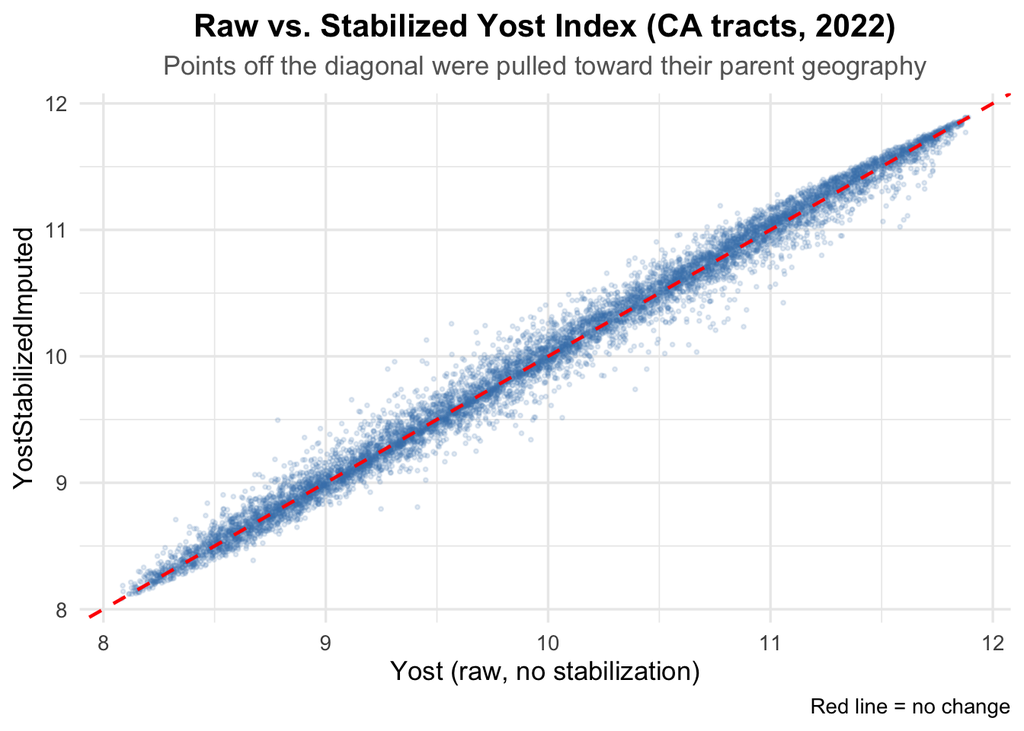

```r
# Compare raw vs stabilized
comparison <- yost_ca$df_yost_raw |>
  dplyr::rename(Yost_raw = Yost) |>
  dplyr::left_join(
    yost_ca$df_yost |>
      dplyr::rename(Yost_stabilized = YostStabilizedImputed),
    by = c("GEOID", "annotation")
  )

ggplot(comparison, aes(x = Yost_raw, y = Yost_stabilized)) +
  geom_point(alpha = 0.15, size = 0.6, color = "steelblue") +
  geom_abline(slope = 1, intercept = 0, color = "red",
              linetype = "dashed", linewidth = 0.8) +
  labs(
    title    = "Raw vs. Stabilized Yost Index (CA tracts, 2022)",
    subtitle = "Points off the diagonal were pulled toward their parent geography",
    x        = "Yost (raw, no stabilization)",
    y        = "YostStabilizedImputed",
    caption  = "Red line = no change"
  ) +
  theme_minimal(base_size = 13) +
  theme(plot.title    = element_text(face = "bold", hjust = 0.5),
        plot.subtitle = element_text(hjust = 0.5, color = "grey40"))
```

### Mapping with `computeYostIndex()`

Because `computeYostIndex()` can return geometry directly, mapping is straightforward:

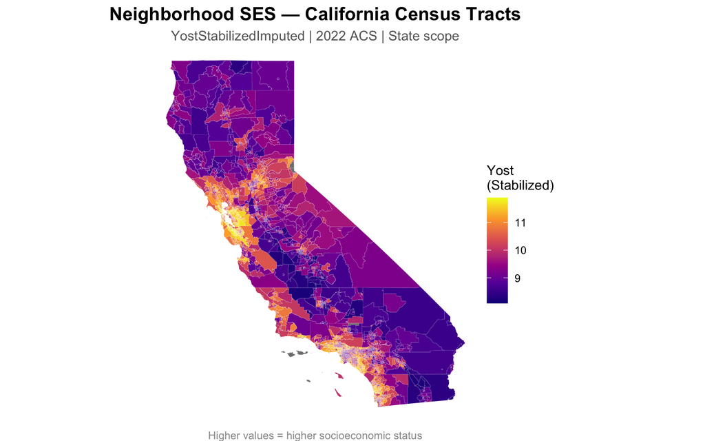

```r
df_map <- yost_ca$df_geometry |>
  dplyr::left_join(yost_ca$df_yost, by = "GEOID")

ggplot(df_map) +
  geom_sf(aes(fill = YostStabilizedImputed), color = "white", linewidth = 0.02) +
  scale_fill_viridis_c(option = "plasma", name = "Yost\n(Stabilized)") +
  labs(
    title    = "Neighborhood SES — California Census Tracts",
    subtitle = "YostStabilizedImputed | 2022 ACS | State scope",
    caption  = "Higher values = higher socioeconomic status"
  ) +
  theme_void() +
  theme(
    plot.title    = element_text(face = "bold", size = 15, hjust = 0.5),
    plot.subtitle = element_text(size = 11, hjust = 0.5, color = "grey40"),
    plot.caption  = element_text(hjust = 0.5, color = "grey60")
  )
```

### When to use `scope = "county"`

County-level scope is only available in `computeYostIndex()`. It ranks geographies within each county, which is useful for within-county resource allocation or studies confined to a single metro area:

```r
# Tracts in Los Angeles County ranked among themselves
yost_la <- computeYostIndex(
  geo    = "tract",
  year   = 2022,
  states = "CA",
  scope  = "county"   # not available in getYostIndex()
)
```

## Decision Guide

| Question | If YES → | If NO → |
| --- | --- | --- |
| Do I have a Census API key? | Either function works | Use getYostIndex() |
| Do I need data for 2024 or later? | Use computeYostIndex() | Use getYostIndex() |
| Do I need county-level scope? | Use computeYostIndex() | Use getYostIndex() |
| Do I need intermediate outputs (raw ACS, factor loadings)? | Use computeYostIndex() | Use getYostIndex() |
| Am I doing a quick analysis or teaching? | Use getYostIndex() | Use computeYostIndex() for full control |

## Further Reading

- Yost K, et al. (2001). Socioeconomic status and breast cancer incidence in California. *Cancer Causes & Control*, 12(8), 703–711.
- Yang J, et al. (2014). Developing an area-based socioeconomic measure from ACS data. *Cancer Prevention Research*, 7(7).
- Package source: https://github.com/HanLabCollaboration/ReproduceYostIndex